# Regression analysis

2023-10-19

## Multiple Linear Regression model

# Objective:

Our goal is to identify an effective regression model for predicting annual earnings.

# Checking for missing values in the data

```r
#check for missing values
colSums(is.na(project))
```

```
##  Annual_Earnings      No_Of_Weeks           Gender        Education
##                0                0                0              409
## Time_paid_employ      WeeklyHours              age          service
##                0                0                0                0
##      JobCategory           Sector
##                0                0
```

Including Education in the analysis will result in a loss of information(i.e. reducing the sample size by 409). We therefore exclude the variable Education in this analysis.

```r
#Removing the education Variable
wages <- project[, !names(project) %in% "Education"]
```

# Fitting the Regression model

```r
model_wage<-lm(Annual_Earnings~.,data=wages)
summary(model_wage)
```

```
##
## Call:
## lm(formula = Annual_Earnings ~ ., data = wages)
##
## Residuals:
##    Min     1Q Median     3Q    Max
## -75805 -15408  -2815   8144 250804
##
## Coefficients:
##                                    Estimate Std. Error t value Pr(>|t|)
## (Intercept)                        -2679.07    8982.18  -0.298  0.76558
## No_Of_Weeks                          629.72     142.68   4.414 1.16e-05 ***
## Genderfemale                      -12231.22    2412.20  -5.071 4.95e-07 ***
## Time_paid_employ                     426.16     161.61   2.637  0.00853 **
## WeeklyHours                          842.83     122.36   6.888 1.16e-11 ***
## age                                   46.49     143.92   0.323  0.74674
## service2 to 5                       3879.10    4230.17   0.917  0.35942
## service6 to 10                     10759.92    4354.29   2.471  0.01368 *
## service10+                          8121.34    5298.48   1.533  0.12574
## JobCategoryprofessional           -14622.51    3317.68  -4.407 1.19e-05 ***
## JobCategoryassistant professional -24960.47    3873.94  -6.443 2.04e-10 ***
## JobCategoryclerical               -32092.67    3179.53 -10.094  < 2e-16 ***
## SectorConstruction & Transport     -7009.64    3051.61  -2.297  0.02188 *
## SectorFinance                       7394.29    2749.74   2.689  0.00732 **
## SectorHealth and education         -7401.59    3624.15  -2.042  0.04146 *
## ---
## Signif. codes:  0 '***' 0.001 '**' 0.01 '*' 0.05 '.' 0.1 ' ' 1
##
## Residual standard error: 29650 on 785 degrees of freedom
## Multiple R-squared:  0.3884, Adjusted R-squared:  0.3775
## F-statistic: 35.61 on 14 and 785 DF,  p-value: < 2.2e-16
```

Although the model explains only 39% of variances in the Annual Earnings, the P-value of <2.2e-16 shows that the model is statistically significant. It can seen seen that the variable Age and service years of 2 to 5 years and 10+ are not significant in the model. We further confirm the assumptions of Regression are met.

# Diagnostic plots

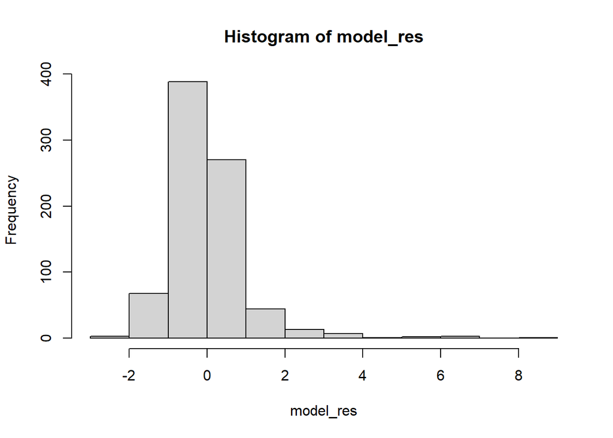

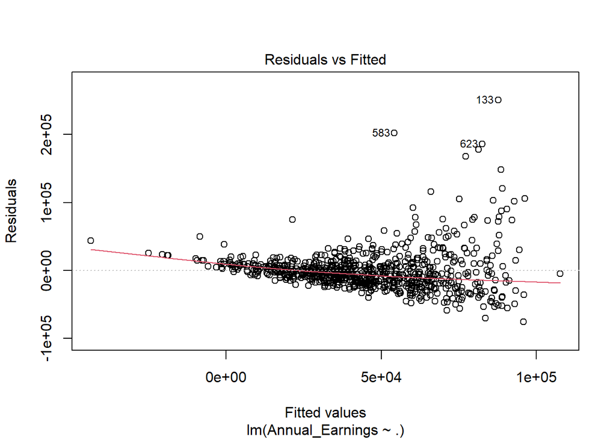

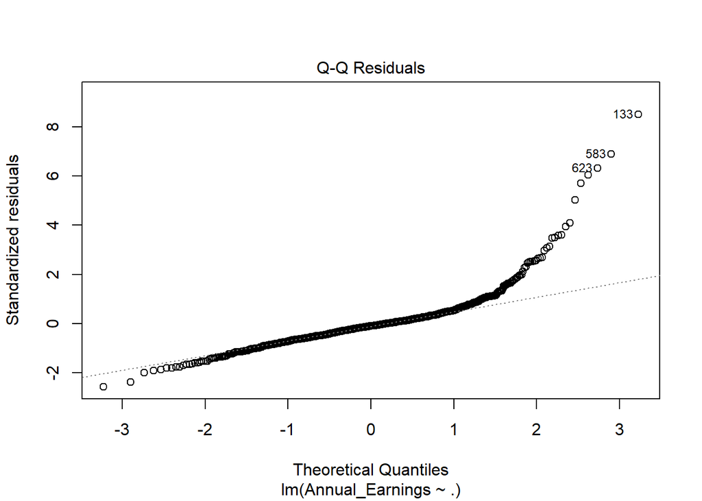

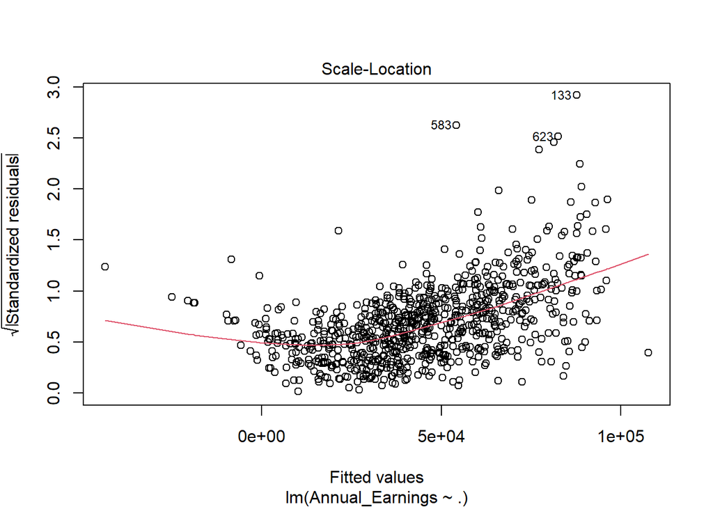

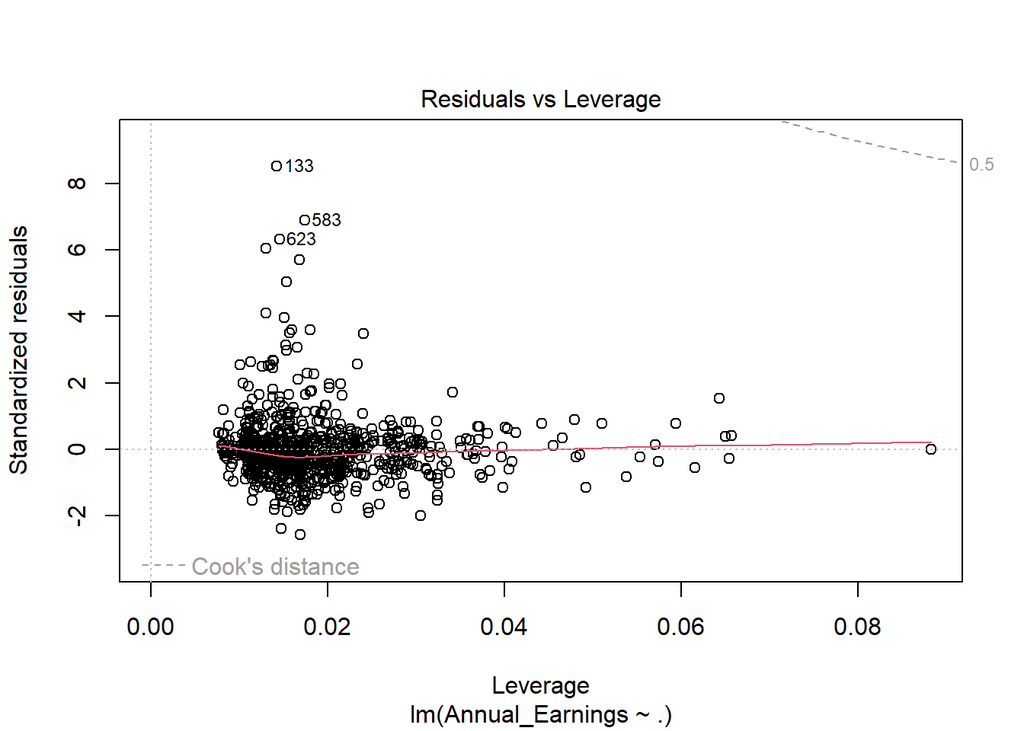

Ideally, when we examine the residual plot, we hope to see no discernible pattern in the residuals. In other words, the red line (representing residuals) should be approximately horizontal and centered around zero in the residual vs. fitted plot. However, in this case, the residual plot reveals some issues:

Non-Normality Assumption: The histogram of standardized residuals indicates that the residuals do not follow a perfect normal distribution. They exhibit deviations from normality, which is an assumption of linear regression.

Heteroscedasticity (Non-Constant Variance): The spread of residuals appears to vary across the range of fitted values, suggesting heteroscedasticity. This means that the variability of errors is not consistent, violating another important assumption of linear regression. from the plots

Model Improvement:

To address these issues, we can take the following steps:

Logarithmic Transformation: We can apply a logarithmic transformation to the dependent variable, this transformation can help stabilize variance and make the relationship between predictors and the response variable more linear.

# Fitting the linear regression model with a logarithmic transformation

```
##
## Call:
## lm(formula = log(Annual_Earnings) ~ ., data = wages)
##
## Residuals:
##      Min       1Q   Median       3Q      Max
## -2.28174 -0.31036 -0.00343  0.31880  2.13515
##
## Coefficients:
##                                    Estimate Std. Error t value Pr(>|t|)
## (Intercept)                        7.741853   0.152241  50.853  < 2e-16 ***
## No_Of_Weeks                        0.029683   0.002418  12.274  < 2e-16 ***
## Genderfemale                      -0.166562   0.040885  -4.074 5.09e-05 ***
## Time_paid_employ                   0.011924   0.002739   4.353 1.52e-05 ***
## WeeklyHours                        0.040615   0.002074  19.584  < 2e-16 ***
## age                               -0.002007   0.002439  -0.823  0.41080
## service2 to 5                      0.042249   0.071698   0.589  0.55585
## service6 to 10                     0.208833   0.073802   2.830  0.00478 **
## service10+                         0.092230   0.089805   1.027  0.30473
## JobCategoryprofessional           -0.135303   0.056232  -2.406  0.01635 *
## JobCategoryassistant professional -0.307276   0.065660  -4.680 3.38e-06 ***
## JobCategoryclerical               -0.536197   0.053891  -9.950  < 2e-16 ***
## SectorConstruction & Transport    -0.145349   0.051722  -2.810  0.00507 **
## SectorFinance                      0.179235   0.046606   3.846  0.00013 ***
## SectorHealth and education        -0.129890   0.061426  -2.115  0.03478 *
## ---
## Signif. codes:  0 '***' 0.001 '**' 0.01 '*' 0.05 '.' 0.1 ' ' 1
##
## Residual standard error: 0.5026 on 785 degrees of freedom
## Multiple R-squared:  0.635,  Adjusted R-squared:  0.6285
## F-statistic: 97.55 on 14 and 785 DF,  p-value: < 2.2e-16
```

#Diagnostic plots

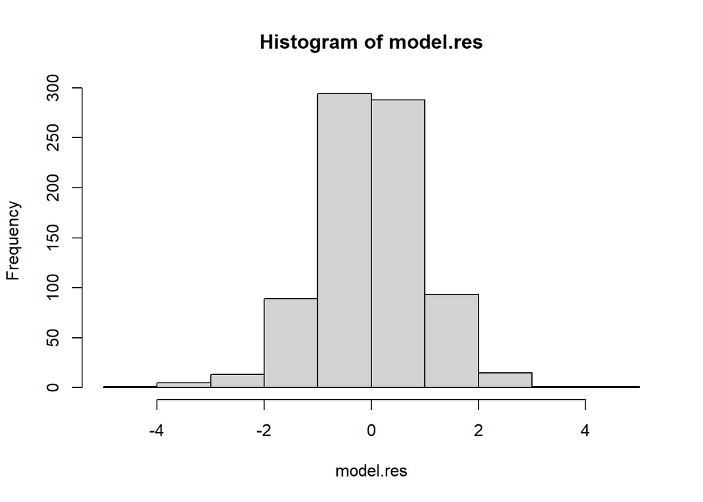

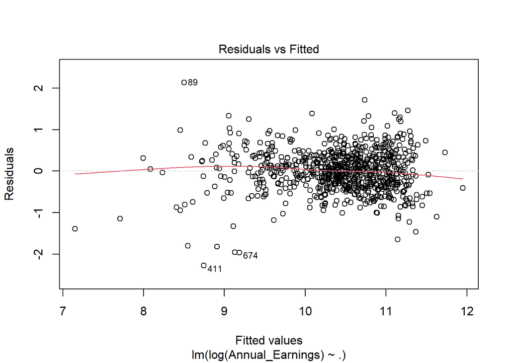

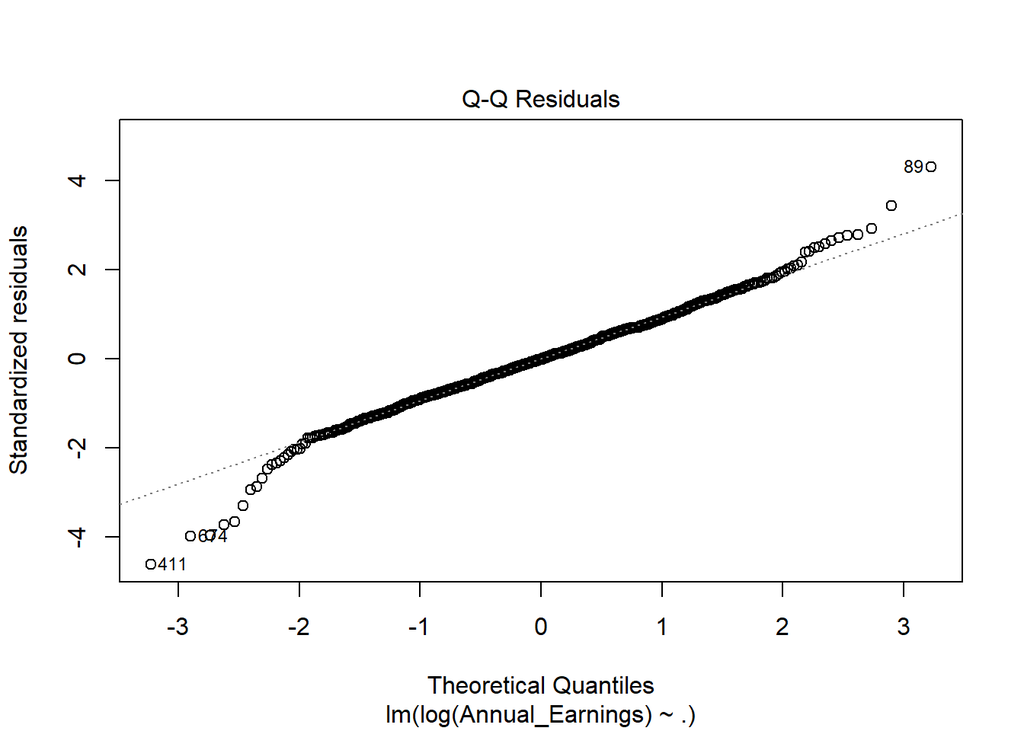

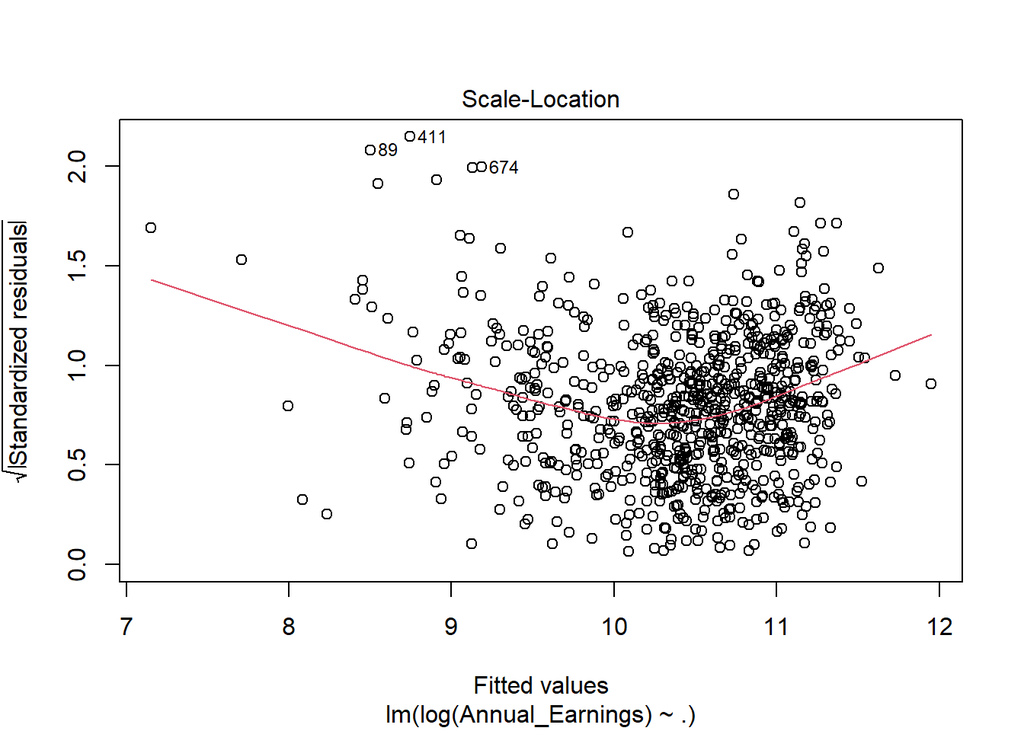

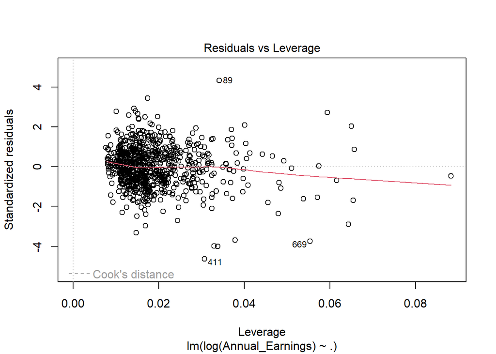

Model Improvement with Logarithmic Transformation:

After applying a logarithmic transformation to the dependent variable (‘Annual_Earnings’), we observed a significant improvement in the model’s performance. Notably, the coefficient of determination, often denoted as $R^2$, increased to 64%. This indicates that our model now explains approximately 64% of the variability in the data, representing a substantial enhancement in predictive power.

Assumption Validation:

Furthermore, the diagnostic plots of the model, including the residual vs. fitted values plot and the histogram of standardized residuals, reveal important insights. The transformation has brought the model closer to meeting the assumptions of linear regression:

Normality Assumption: The histogram of standardized residuals now exhibits a distribution that approximates normality more closely. This aligns with the assumption that the residuals should follow a normal distribution, improving the model’s validity.

Constant Variance (Homoscedasticity): The spread of residuals across the range of fitted values appears to be more consistent, indicating that the model’s variance assumption is better satisfied. This is crucial for reliable predictions and valid statistical inferences.

Overall, the logarithmic transformation of the dependent variable has led to a model that not only explains a substantial portion of the data’s variability but also aligns more closely with the fundamental assumptions of linear regression. This enhanced model provides more reliable predictions and a stronger foundation for drawing meaningful insights from the data.

**TESTING FOR MULTICOLLINEARITY**

```r
vif(model.wage)
```

```
##                      GVIF Df GVIF^(1/(2*Df))
## No_Of_Weeks      1.383858  1        1.176375
## Gender           1.285137  1        1.133639
## Time_paid_employ 2.824923  1        1.680751
## WeeklyHours      1.178668  1        1.085665
## age              2.489524  1        1.577823
## service          2.172410  3        1.138039
## JobCategory      1.430212  3        1.061451
## Sector           1.253590  3        1.038387
```

```r
outliers <- boxplot(wages$Annual_Earnings, plot=FALSE)$out
##remove the outliers
wages_clean<- wages[-which(wages$Annual_Earnings %in% outliers),]
```

# Refitting the model without the age variable

```
##
## Call:
## lm(formula = log(Annual_Earnings) ~ No_Of_Weeks + Gender + Time_paid_employ +
##     WeeklyHours + service + JobCategory + Sector, data = wages)
##
## Residuals:
##      Min       1Q   Median       3Q      Max
## -2.25180 -0.30920  0.00242  0.32244  2.13790
##
## Coefficients:
##                                    Estimate Std. Error t value Pr(>|t|)
## (Intercept)                        7.683701   0.134820  56.992  < 2e-16 ***
## No_Of_Weeks                        0.029512   0.002409  12.251  < 2e-16 ***
## Genderfemale                      -0.169375   0.040733  -4.158 3.56e-05 ***
## Time_paid_employ                   0.010465   0.002088   5.013 6.63e-07 ***
## WeeklyHours                        0.040919   0.002041  20.053  < 2e-16 ***
## service2 to 5                      0.047161   0.071435   0.660 0.509318
## service6 to 10                     0.208544   0.073786   2.826 0.004828 **
## service10+                         0.091580   0.089783   1.020 0.308035
## JobCategoryprofessional           -0.133127   0.056158  -2.371 0.018001 *
## JobCategoryassistant professional -0.305352   0.065605  -4.654 3.81e-06 ***
## JobCategoryclerical               -0.533883   0.053806  -9.922  < 2e-16 ***
## SectorConstruction & Transport    -0.143970   0.051685  -2.786 0.005472 **
## SectorFinance                      0.181555   0.046511   3.903 0.000103 ***
## SectorHealth and education        -0.131733   0.061373  -2.146 0.032144 *
## ---
## Signif. codes:  0 '***' 0.001 '**' 0.01 '*' 0.05 '.' 0.1 ' ' 1
##
## Residual standard error: 0.5025 on 786 degrees of freedom
## Multiple R-squared:  0.6347, Adjusted R-squared:  0.6287
## F-statistic:   105 on 13 and 786 DF,  p-value: < 2.2e-16
```

**PARTIAL F TEST** Next, using the partial F.test, we decide if the categorical variables are worth including in the regression model.

```
## Analysis of Variance Table
##
## Model 1: log(Annual_Earnings) ~ No_Of_Weeks + WeeklyHours + Time_paid_employ
## Model 2: log(Annual_Earnings) ~ No_Of_Weeks + Gender + WeeklyHours + Time_paid_employ
##   Res.Df    RSS Df Sum of Sq      F    Pr(>F)
## 1    796 264.68
## 2    795 247.42  1    17.264 55.472 2.472e-13 ***
## ---
## Signif. codes:  0 '***' 0.001 '**' 0.01 '*' 0.05 '.' 0.1 ' ' 1
```

```
## Analysis of Variance Table
##
## Model 1: log(Annual_Earnings) ~ No_Of_Weeks + WeeklyHours + Time_paid_employ
## Model 2: log(Annual_Earnings) ~ No_Of_Weeks + WeeklyHours + Sector + Time_paid_employ
##   Res.Df    RSS Df Sum of Sq      F   Pr(>F)
## 1    796 264.68
## 2    793 251.24  3    13.436 14.136 5.54e-09 ***
## ---
## Signif. codes:  0 '***' 0.001 '**' 0.01 '*' 0.05 '.' 0.1 ' ' 1
```

```
## Analysis of Variance Table
##
## Model 1: log(Annual_Earnings) ~ No_Of_Weeks + WeeklyHours + Time_paid_employ
## Model 2: log(Annual_Earnings) ~ No_Of_Weeks + WeeklyHours + JobCategory +
##     Time_paid_employ
##   Res.Df    RSS Df Sum of Sq      F    Pr(>F)
## 1    796 264.68
## 2    793 223.36  3    41.318 48.896 < 2.2e-16 ***
## ---
## Signif. codes:  0 '***' 0.001 '**' 0.01 '*' 0.05 '.' 0.1 ' ' 1
```

```
## Analysis of Variance Table
##
## Model 1: log(Annual_Earnings) ~ No_Of_Weeks + WeeklyHours + Time_paid_employ
## Model 2: log(Annual_Earnings) ~ No_Of_Weeks + WeeklyHours + service +
##     Time_paid_employ
##   Res.Df    RSS Df Sum of Sq      F    Pr(>F)
## 1    796 264.68
## 2    793 258.88  3    5.8049 5.9272 0.0005327 ***
## ---
## Signif. codes:  0 '***' 0.001 '**' 0.01 '*' 0.05 '.' 0.1 ' ' 1
```

The results of the partial F-tests indicate that the inclusion of categorical variables significantly enhances the model’s fit. These categorical variables contribute substantially to predicting the annual earnings of the workers.

# Final Regression Model

```
##
## Call:
## lm(formula = log(Annual_Earnings) ~ No_Of_Weeks + Gender + Time_paid_employ +
##     WeeklyHours + service + JobCategory + Sector, data = wages)
##
## Residuals:
##      Min       1Q   Median       3Q      Max
## -2.25180 -0.30920  0.00242  0.32244  2.13790
##
## Coefficients:
##                                    Estimate Std. Error t value Pr(>|t|)
## (Intercept)                        7.683701   0.134820  56.992  < 2e-16 ***
## No_Of_Weeks                        0.029512   0.002409  12.251  < 2e-16 ***
## Genderfemale                      -0.169375   0.040733  -4.158 3.56e-05 ***
## Time_paid_employ                   0.010465   0.002088   5.013 6.63e-07 ***
## WeeklyHours                        0.040919   0.002041  20.053  < 2e-16 ***
## service2 to 5                      0.047161   0.071435   0.660 0.509318
## service6 to 10                     0.208544   0.073786   2.826 0.004828 **
## service10+                         0.091580   0.089783   1.020 0.308035
## JobCategoryprofessional           -0.133127   0.056158  -2.371 0.018001 *
## JobCategoryassistant professional -0.305352   0.065605  -4.654 3.81e-06 ***
## JobCategoryclerical               -0.533883   0.053806  -9.922  < 2e-16 ***
## SectorConstruction & Transport    -0.143970   0.051685  -2.786 0.005472 **
## SectorFinance                      0.181555   0.046511   3.903 0.000103 ***
## SectorHealth and education        -0.131733   0.061373  -2.146 0.032144 *
## ---
## Signif. codes:  0 '***' 0.001 '**' 0.01 '*' 0.05 '.' 0.1 ' ' 1
##
## Residual standard error: 0.5025 on 786 degrees of freedom
## Multiple R-squared:  0.6347, Adjusted R-squared:  0.6287
## F-statistic:   105 on 13 and 786 DF,  p-value: < 2.2e-16
```

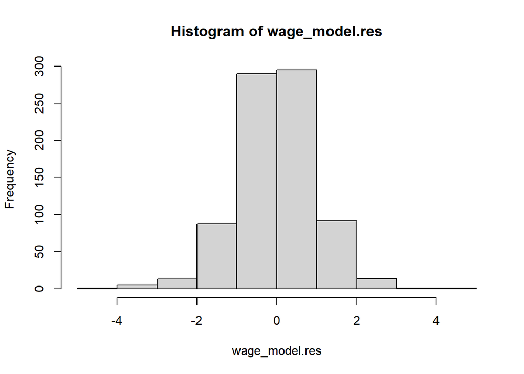

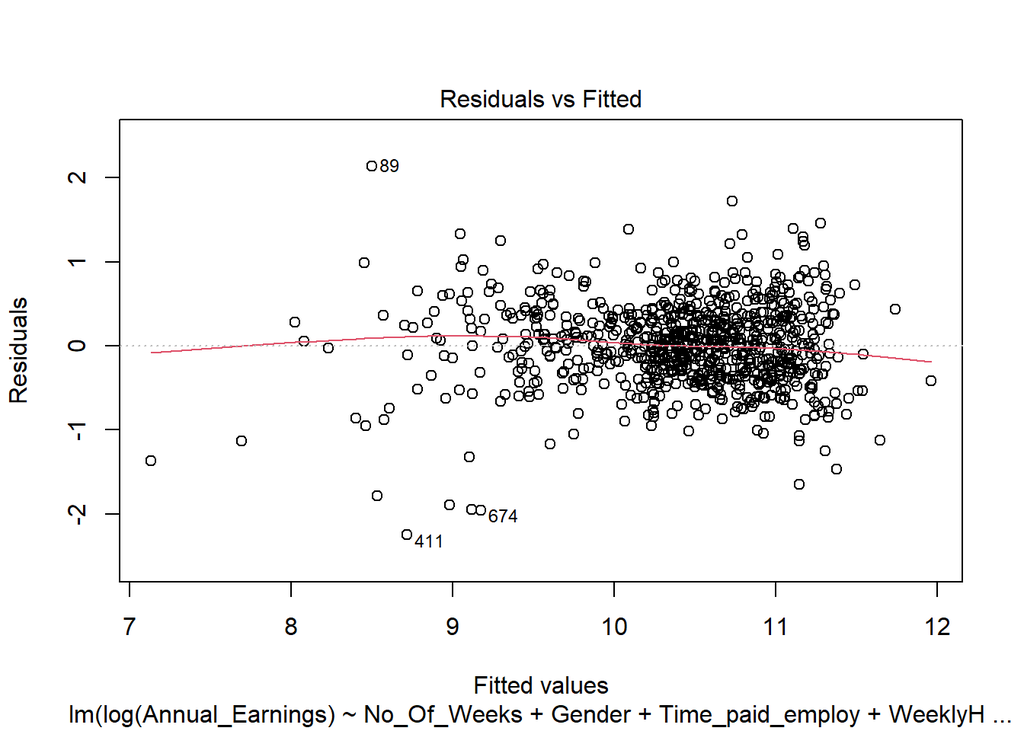

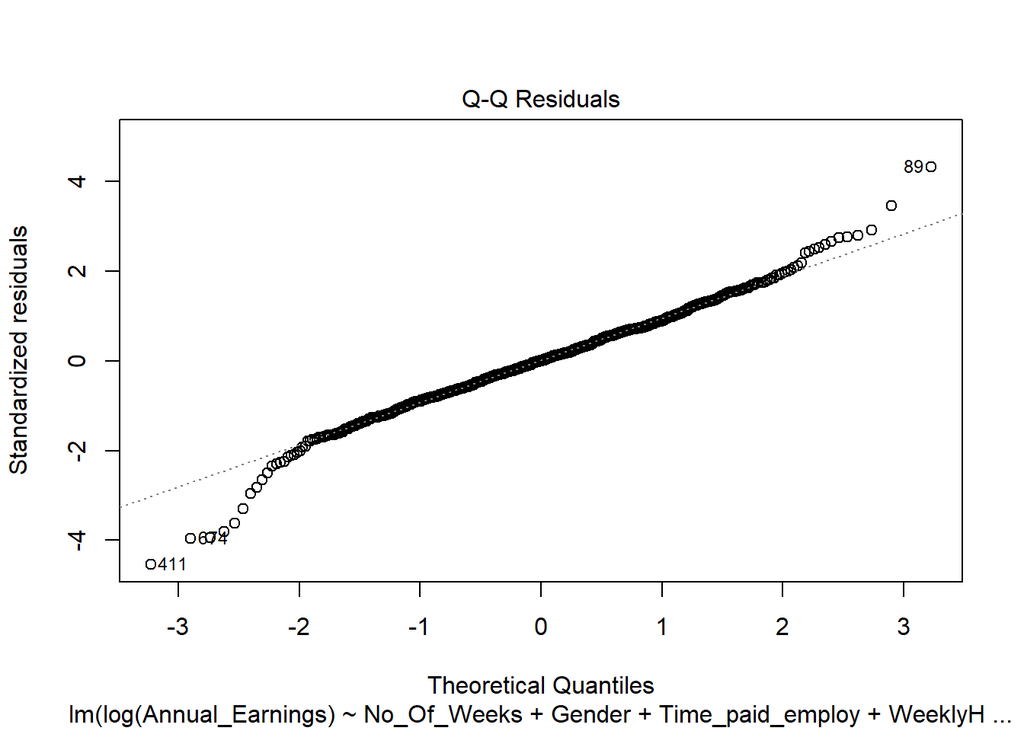

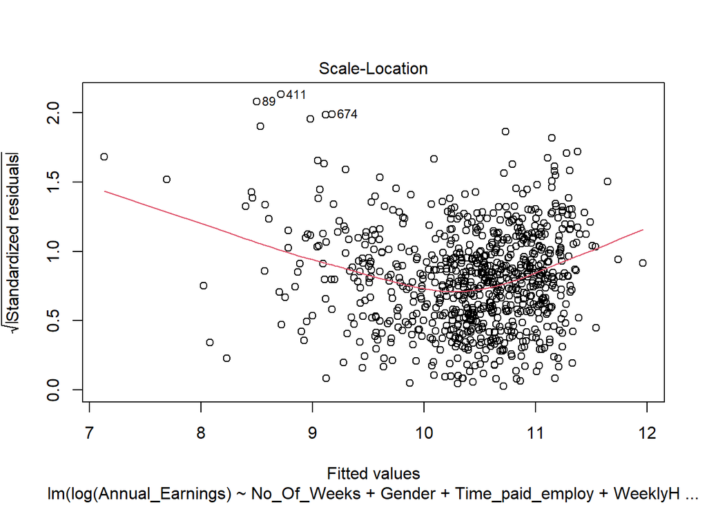

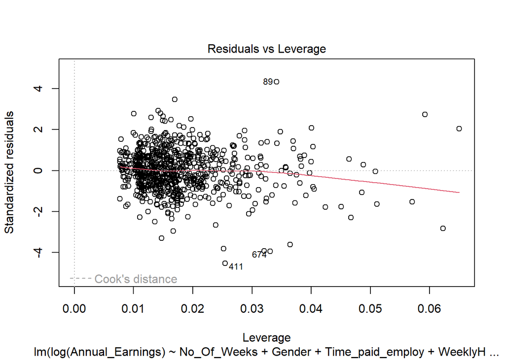

```r
round((exp(wage_model$coefficients)-1)*100,3)
```

```
##                       (Intercept)                       No_Of_Weeks
##                        217164.656                             2.995
##                      Genderfemale                  Time_paid_employ
##                           -15.581                             1.052
##                       WeeklyHours                     service2 to 5
##                             4.177                             4.829
##                    service6 to 10                        service10+
##                            23.188                             9.590
##           JobCategoryprofessional JobCategoryassistant professional
##                           -12.465                           -26.314
##               JobCategoryclerical    SectorConstruction & Transport
##                           -41.368                           -13.409
##                     SectorFinance        SectorHealth and education
##                            19.908                           -12.343
```

Coefficient Interpretation: - No_Of_Weeks: An additional week of work will lead to a 3% increase in annual earnings controlling for other variables.

The adjusted R-squared value of 0.629 indicates that approximately 62.9% of the variability in annual earnings is explained by this transformed model. The F-statistic is highly significant (p-value < 0.001), suggesting that at least one of the predictor variables is related to the annual earnings.

## Assessing the predictive performance of the regression model

```r
# Set the seed for reproducibility
set.seed(123)

# Define the training control parameters
train.control <- trainControl(method = "repeatedcv", number = 10, repeats = 3)

# Train a linear regression model using the specified predictors
model_val <- train(
  log(Annual_Earnings) ~ No_Of_Weeks + Gender + Time_paid_employ + WeeklyHours + service + JobCategory + Sector,
  data = wages,
  method = "lm",
  trControl = train.control
)

# Print and summarize the results of the model validation
print(model_val)
```

```
## Linear Regression
##
## 800 samples
##   7 predictor
##
## No pre-processing
## Resampling: Cross-Validated (10 fold, repeated 3 times)
## Summary of sample sizes: 720, 720, 720, 720, 720, 720, ...
## Resampling results:
##
##   RMSE       Rsquared  MAE
##   0.5065173  0.622107  0.3877406
##
## Tuning parameter 'intercept' was held constant at a value of TRUE
```

The low RMSE obtained of 0.5065 and $R^2$= 0.62 shows that the model performed well in predicting annual earnings.

The diagnostic plot of the transformed linear regression model reveals the presence of outlying values, indicating that some data points may have a disproportionate influence on the model. To address this issue and improve the model’s robustness, we have opted to fit a robust regression model to predict annual earnings. This robust regression approach is better equipped to handle outliers and provide more reliable predictions in the presence of such data anomalies.

```r
library(robustbase)
robust_model<-lmrob(log(Annual_Earnings) ~ No_Of_Weeks+Gender+Time_paid_employ+WeeklyHours+service+JobCategory+Sector, data = wages,control=lmrob.control(max.it=100))
summary(robust_model)
```

```
##
## Call:
## lmrob(formula = log(Annual_Earnings) ~ No_Of_Weeks + Gender + Time_paid_employ +
##     WeeklyHours + service + JobCategory + Sector, data = wages, control = lmrob.control(max.it = 100))
##  \--> method = "MM"
## Residuals:
##      Min       1Q   Median       3Q      Max
## -2.57888 -0.29689 -0.00346  0.29197  2.01795
##
## Coefficients:
##                                    Estimate Std. Error t value Pr(>|t|)
## (Intercept)                        7.966168   0.196996  40.438  < 2e-16 ***
## No_Of_Weeks                        0.030774   0.003544   8.684  < 2e-16 ***
## Genderfemale                      -0.202215   0.039438  -5.127 3.70e-07 ***
## Time_paid_employ                   0.009561   0.002121   4.507 7.59e-06 ***
## WeeklyHours                        0.032026   0.002853  11.224  < 2e-16 ***
## service2 to 5                      0.024587   0.075593   0.325  0.74508
## service6 to 10                     0.202915   0.080460   2.522  0.01187 *
## service10+                         0.150379   0.097178   1.547  0.12216
## JobCategoryprofessional           -0.087881   0.070404  -1.248  0.21231
## JobCategoryassistant professional -0.303700   0.074713  -4.065 5.29e-05 ***
## JobCategoryclerical               -0.470096   0.066659  -7.052 3.86e-12 ***
## SectorConstruction & Transport    -0.219941   0.048901  -4.498 7.90e-06 ***
## SectorFinance                      0.144944   0.044292   3.272  0.00111 **
## SectorHealth and education        -0.162990   0.051940  -3.138  0.00176 **
## ---
## Signif. codes:  0 '***' 0.001 '**' 0.01 '*' 0.05 '.' 0.1 ' ' 1
##
## Robust residual standard error: 0.4206
## Multiple R-squared:  0.6339, Adjusted R-squared:  0.6279
## Convergence in 17 IRWLS iterations
##
## Robustness weights:
##  6 observations c(34,89,304,411,669,674)
##   are outliers with |weight| = 0 ( < 0.00012);
##  68 weights are ~= 1. The remaining 726 ones are summarized as
##     Min.  1st Qu.   Median     Mean  3rd Qu.     Max.
## 0.007161 0.851900 0.948300 0.890200 0.984900 0.999000
## Algorithmic parameters:
##        tuning.chi                bb        tuning.psi        refine.tol
##         1.548e+00         5.000e-01         4.685e+00         1.000e-07
##           rel.tol         scale.tol         solve.tol          zero.tol
##         1.000e-07         1.000e-10         1.000e-07         1.000e-10
##       eps.outlier             eps.x warn.limit.reject warn.limit.meanrw
##         1.250e-04         1.039e-10         5.000e-01         5.000e-01
##      nResample         max.it       best.r.s       k.fast.s          k.max
##            500            100              2              1            200
##    maxit.scale      trace.lev            mts     compute.rd fast.s.large.n
##            200              0           1000              0           2000
##                   psi           subsampling                   cov
##            "bisquare"         "nonsingular"         ".vcov.avar1"
## compute.outlier.stats
##                  "SM"
## seed : int(0)
```

In contrast, the robust regression model yields promising results, with an R-squared value of 63%, signifying that it explains a substantial portion of the data’s variability. What sets it apart is its superior performance in predicting annual earnings compared to the ordinary multiple linear regression models. This is evident from the significantly lower residual standard error of 0.4206, which outperforms the multiple regression model’s value of 0.5025.

# Objective:

The primary objective of this project is to develop a logistic regression model considering Age, DebtRatio, YearlyIncome, and LatePayment, as potential predictors for credit default.

```
## # A tibble: 6 × 6
##      ID Default   Age DebtRatio YearlyIncome LatePayment
##   <dbl>   <dbl> <dbl>     <dbl>        <dbl>       <dbl>
## 1 17633       0    54     0.604         126            0
## 2  1184       0    79     0.305         126            1
## 3 15604       0    59     0.261         126.           0
## 4 14956       0    62     0.255         126.           0
## 5   537       1    52     0.525         126.           1
## 6 50805       1    43     0.116         126.           1
```

# Check for missing values

```r
colSums(is.na(credit))
```

```
##           ID      Default          Age    DebtRatio YearlyIncome  LatePayment
##            0            0            0            0            0            0
```

There are no missing values in the data , next we proceed with exploratory analysis

Exploratory Analysis

```r
cred <- as_tibble(credit[,c(3,4,5)])
cred.sum <- cred %>%
  summarise(across(where(is.numeric),list(min = ~min(.),
                      q25 = ~quantile(., 0.25),
                      median = ~median(.),
                      q75 = ~quantile(., 0.75),
                      max = ~max(.),
                      mean = ~mean(.),
                      sd = ~sd(.))))


# reshape the output for presentation in a table
cred.sum %>% gather(stat, val) %>%
  separate(stat, into = c("var", "stat"), sep = "_") %>%
  spread(stat, val) %>%
  select(var, min, q25, median, q75, max, mean, sd) %>%
  kable() %>%
  kable_styling()
```

| var | min | q25 | median | q75 | max | mean | sd |
| --- | --- | --- | --- | --- | --- | --- | --- |
| Age | 22 | 39.7500000 | 49.000000 | 59.0000000 | 98.000000 | 49.7555556 | 13.9584726 |
| DebtRatio | 0 | 0.1284658 | 0.304413 | 0.5032904 | 7.348452 | 0.3651438 | 0.3864143 |
| YearlyIncome | 18 | 39.6000000 | 59.196000 | 84.0000000 | 126.000000 | 62.8937733 | 28.4234135 |

To account for variation in the numerical variables and ensure consistent scales, we intend to standardize the variables.

| var | min | q25 | median | q75 | max | mean | sd |
| --- | --- | --- | --- | --- | --- | --- | --- |
| Age | 1.5761037 | 2.8477328 | 3.5104127 | 4.226824 | 7.020825 | 3.5645416 | 1 |
| DebtRatio | 0.0000000 | 0.3324562 | 0.7877894 | 1.302463 | 19.017032 | 0.9449542 | 1 |
| YearlyIncome | 0.6332807 | 1.3932176 | 2.0826492 | 2.955310 | 4.432965 | 2.2127453 | 1 |

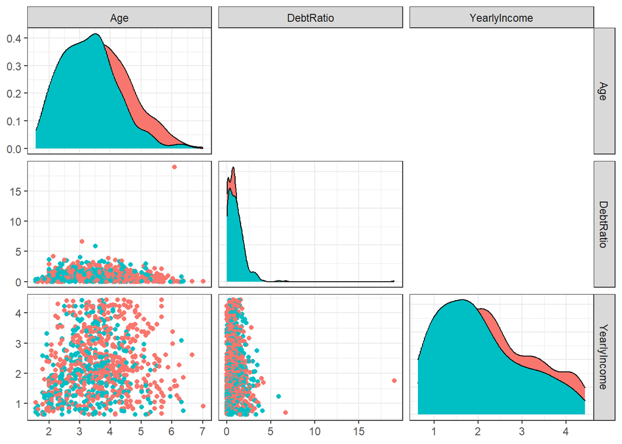

```r
# Create a pairs plot to visualize relationships between variables
ggpairs(data = Cred[,c(1,2,3)], upper = list(continuous = "blank", discrete = "blank"), lower=list(continuous = "points", discrete="blank"), diag = list(continuous = "densityDiag", discrete="blankDiag"), ggplot2::aes(colour=Cred$Default)) + theme_bw()
```

```r
# Calculate the correlation matrix to assess the strength and direction of relationships
correlation_matrix <- cor(Cred[,c(1,2,3)])
print(correlation_matrix)
```

```
##                       Age    DebtRatio YearlyIncome
## Age           1.000000000 -0.007186796    0.1328391
## DebtRatio    -0.007186796  1.000000000   -0.1079875
## YearlyIncome  0.132839118 -0.107987467    1.0000000
```

# Boxplots

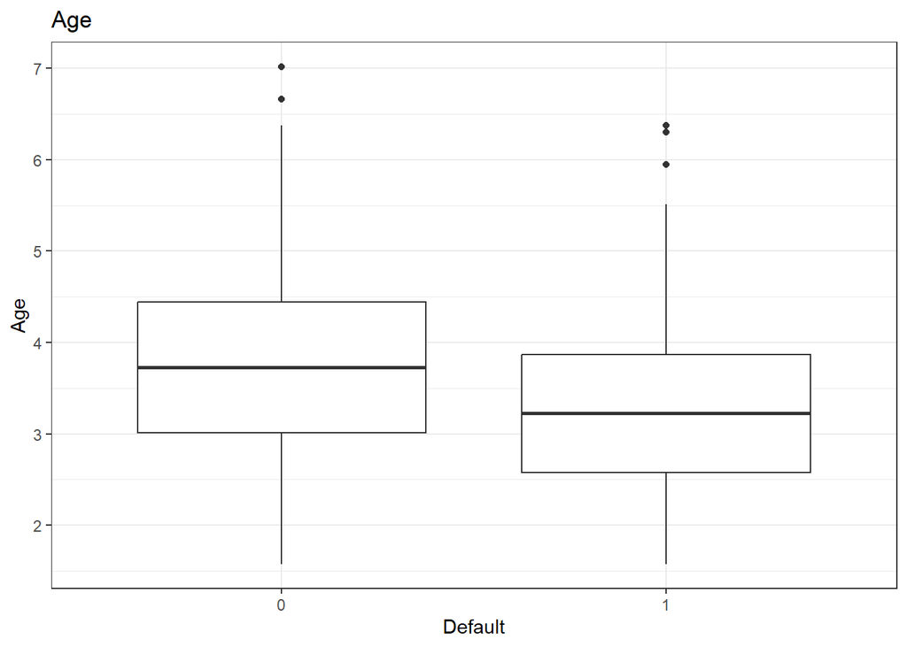

```r
# Create boxplots for Age, DebtRatio, and YearlyIncome by Default status
ggplot(data = Cred, aes(x = Default, y = Age)) + geom_boxplot() + theme_bw() + ggtitle('Age')
```

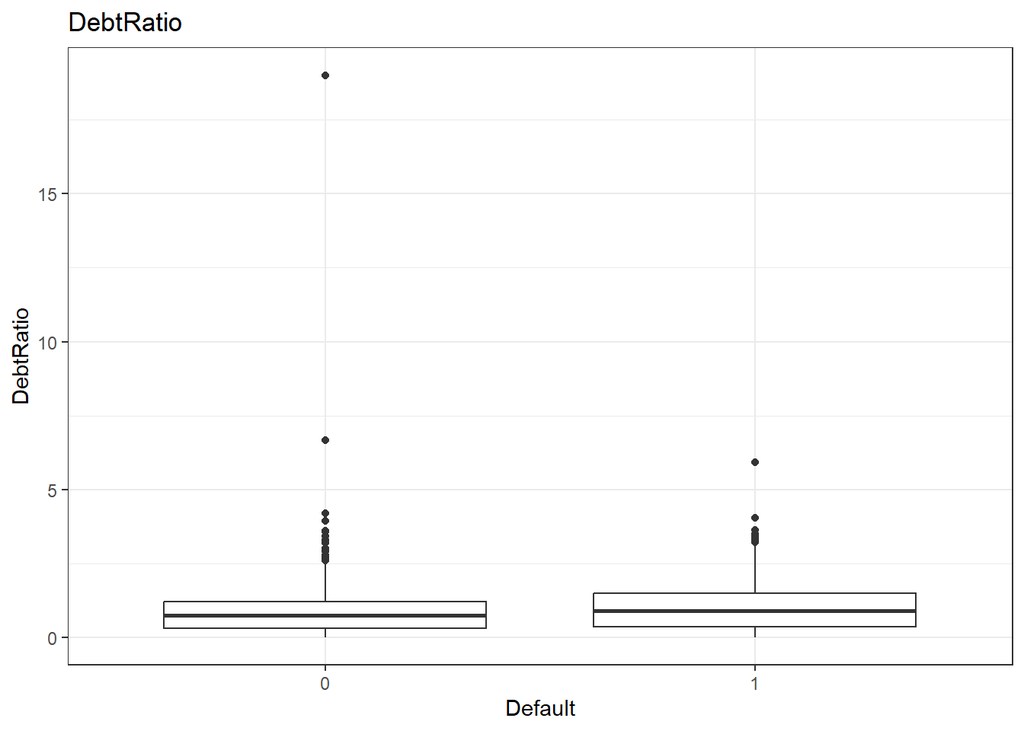

```r
ggplot(data = Cred, aes(x = Default, y = DebtRatio)) + geom_boxplot() + theme_bw() + ggtitle('DebtRatio')
```

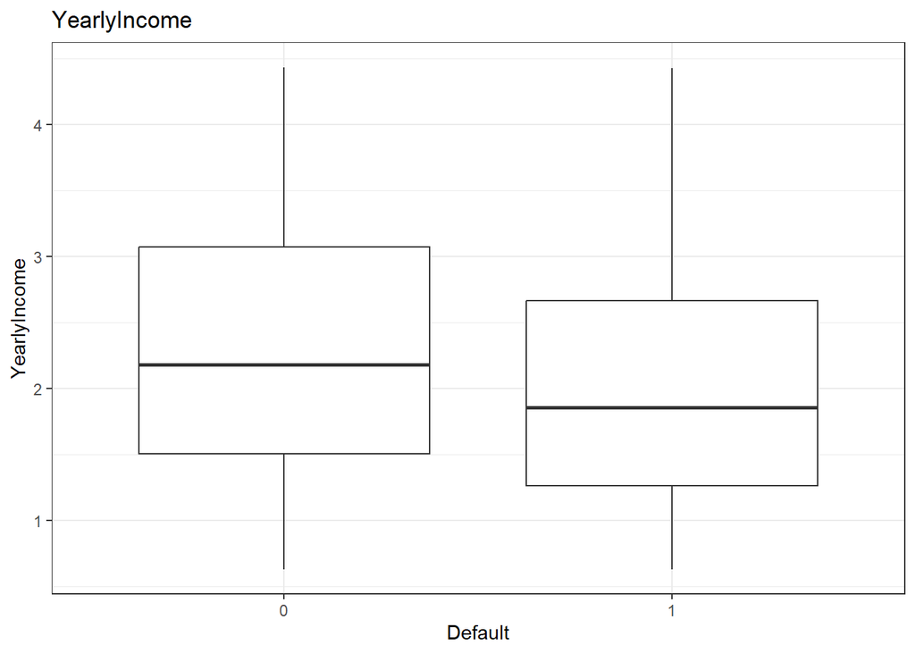

```r
ggplot(data = Cred, aes(x = Default, y = YearlyIncome)) + geom_boxplot() + theme_bw() + ggtitle('YearlyIncome')
```

```r
# Identify outliers for Age and DebtRatio
out <- boxplot(Cred$Age, plot = FALSE)$out
out2 <- boxplot(Cred$DebtRatio, plot = FALSE)$out
```

# Fitting the Credit model

```r
##fit the logistic regression model
model<-glm(Default~Age+DebtRatio+YearlyIncome+LatePayment,data=Cred,family = "binomial")
summary(model)
```

```
##
## Call:
## glm(formula = Default ~ Age + DebtRatio + YearlyIncome + LatePayment,
##     family = "binomial", data = Cred)
##
## Coefficients:
##              Estimate Std. Error z value Pr(>|z|)
## (Intercept)   0.88105    0.32872   2.680  0.00736 **
## Age          -0.42052    0.08210  -5.122 3.02e-07 ***
## DebtRatio     0.07527    0.07403   1.017  0.30928
## YearlyIncome -0.23806    0.08040  -2.961  0.00307 **
## LatePayment1  1.85993    0.17153  10.843  < 2e-16 ***
## ---
## Signif. codes:  0 '***' 0.001 '**' 0.01 '*' 0.05 '.' 0.1 ' ' 1
##
## (Dispersion parameter for binomial family taken to be 1)
##
##     Null deviance: 1192.3  on 899  degrees of freedom
## Residual deviance: 1006.3  on 895  degrees of freedom
## AIC: 1016.3
##
## Number of Fisher Scoring iterations: 4
```

```r
#calculate odds ratio
exp(cbind(coef(model), confint(model)))
```

```
##                            2.5 %    97.5 %
## (Intercept)  2.4134257 1.2707197 4.6192578
## Age          0.6567064 0.5576807 0.7696570
## DebtRatio    1.0781788 0.9218715 1.2461707
## YearlyIncome 0.7881539 0.6722399 0.9215976
## LatePayment1 6.4232850 4.6087726 9.0340412
```

```r
#Variable Importance
varImp(model)
```

```
##                Overall
## Age           5.122040
## DebtRatio     1.016729
## YearlyIncome  2.961029
## LatePayment1 10.843393
```

Odds ratio interpretation:

- Age (0.6567064): For each one-unit increase in age, the odds of default decrease by a factor of approximately 0.6567, holding all other variables constant. This suggests that older individuals are less likely to default compared to younger ones.
- DebtRatio (1.0781788): For each one-unit increase in the debt ratio, the odds of default increase by a factor of approximately 1.0782, holding all other variables constant. However, the 95% CI includes 1. This suggests that the effect of DebtRatio on default may not be statistically significant.
- YearlyIncome (0.7881539): For each one-unit increase in yearly income, the odds of default decrease by a factor of approximately 0.7882, holding all other variables constant. This implies that individuals with higher yearly incomes are less likely to default.
- LatePayment (yes) (6.4232850): This is the estimated odds ratio for individuals with a late payment history (LatePayment = 1) compared to those with no late payment history (LatePayment = 0). It suggests that individuals with a late payment history are approximately 6.4233 times more likely to default than those with no late payment history.

In summary, the variable importance results suggest that Age and LatePayment (yes) are the most influential predictors of default, while DebtRatio has relatively low importance in the model. YearlyIncome falls in between, indicating moderate importance.

# Model Validity and Classification performance

```r
# Set the seed for reproducibility
set.seed(123)

# Define the training control parameters
train.control <- trainControl(method = "repeatedcv", number = 10, repeats = 3)

# Train a linear regression model using the specified predictors
model_val2 <- train(
  Default~Age+DebtRatio+YearlyIncome+LatePayment,
  family = "binomial",
  data = Cred,
  method = "glm",
  trControl = train.control
)

# Print and summarize the results of the model validation
print(model_val2)
```

```
## Generalized Linear Model
##
## 900 samples
##   4 predictor
##   2 classes: '0', '1'
##
## No pre-processing
## Resampling: Cross-Validated (10 fold, repeated 3 times)
## Summary of sample sizes: 809, 810, 810, 810, 811, 810, ...
## Resampling results:
##
##   Accuracy   Kappa
##   0.7289037  0.3855585
```

In summary, the GLM has an accuracy of about 72.89%, which means it is reasonably good at predicting credit default based on the given predictor variables. However, the Kappa statistic of 0.3855585 suggests that there is some room for improvement, and the model’s performance is better than chance but not extremely strong.

The analysis is repeated with outliers removed to observe whether there will be an improvement in the performance metrics of the model.

```r
# Remove rows in the 'Cred' dataset where 'Age' values are identified as outliers based on the 'out' list
Cred <- Cred[-which(Cred$Age %in% out),]

# Remove rows in the 'Cred' dataset where 'DebtRatio' values are identified as outliers based on the 'out2' list
Cred <- Cred[-which(Cred$DebtRatio %in% out2),]
```

```r
##fit the logistic regression model without outliers

model2<-glm(Default~Age+DebtRatio+YearlyIncome+LatePayment,data=Cred,family = "binomial")
summary(model2)
```

```
##
## Call:
## glm(formula = Default ~ Age + DebtRatio + YearlyIncome + LatePayment,
##     family = "binomial", data = Cred)
##
## Coefficients:
##              Estimate Std. Error z value Pr(>|z|)
## (Intercept)   0.87146    0.34691   2.512    0.012 *
## Age          -0.43526    0.08564  -5.082 3.73e-07 ***
## DebtRatio     0.09419    0.12354   0.762    0.446
## YearlyIncome -0.22530    0.08200  -2.748    0.006 **
## LatePayment1  1.85037    0.17577  10.527  < 2e-16 ***
## ---
## Signif. codes:  0 '***' 0.001 '**' 0.01 '*' 0.05 '.' 0.1 ' ' 1
##
## (Dispersion parameter for binomial family taken to be 1)
##
##     Null deviance: 1139.94  on 864  degrees of freedom
## Residual deviance:  961.79  on 860  degrees of freedom
## AIC: 971.79
##
## Number of Fisher Scoring iterations: 4
```

```r
varImp(model2)
```

```
##                 Overall
## Age           5.0822998
## DebtRatio     0.7623946
## YearlyIncome  2.7475568
## LatePayment1 10.5273930
```

```r
#Cross-Validation
# Set the seed for reproducibility
set.seed(123)

# Define the training control parameters
train.control <- trainControl(method = "repeatedcv", number = 10, repeats = 3)

# Train a linear regression model using the specified predictors
model_val3 <- train(
  Default~Age+DebtRatio+YearlyIncome+LatePayment,
  family = "binomial",
  data = Cred,
  method = "glm",
  trControl = train.control
)

# Print and summarize the results of the model validation
print(model_val3)
```

```
## Generalized Linear Model
##
## 865 samples
##   4 predictor
##   2 classes: '0', '1'
##
## No pre-processing
## Resampling: Cross-Validated (10 fold, repeated 3 times)
## Summary of sample sizes: 778, 778, 779, 779, 778, 779, ...
## Resampling results:
##
##   Accuracy   Kappa
##   0.7341219  0.3894881
```